# Assignment_Four

Terence Lau

5/5/2019

Use the attached data set ???t8-6.txt: National Track Records for Men??? to do the following data analysis. The data introduction can be found in Table 8.6, P.477.

## Question One

Perform a principal component analysis based on the correlation matrix.

1. Write out the first two principal components as a linear combination of all the original variables, try to interpret the first two components.
2. Give the cumulative contribution of the first two components and interpret.
3. Make a scatter plot for these countries based on the first two principal component scores. Is there any pattern that you can find from the scatter plot?
4. Rank the countries based on their score on the first principal component. Does this ranking correspond with your intuitive notion of athletic excellence for the various countries?

```r
database <- read.table("~/T8-6.txt", header = F)
database <- as.data.frame(database)
database <- database[,-1]
eig <- eigen(cor(database))
eigen <- dim(database[,-1])[1]
eig
```

```
## eigen() decomposition
## $values
## [1] 6.703289951 0.638410110 0.227524494 0.205849181 0.097577441 0.070687912
## [7] 0.046942050 0.009718862
##
## $vectors
##            [,1]        [,2]         [,3]        [,4]        [,5]
## [1,] -0.3323877 -0.52939911 -0.343859303  0.38074525 -0.29967117
## [2,] -0.3460511 -0.47039050  0.003786104  0.21702322  0.54143422
## [3,] -0.3391240 -0.34532929  0.067060507 -0.85129980 -0.13298631
## [4,] -0.3530134  0.08945523  0.782711152  0.13427911  0.22728254
## [5,] -0.3659849  0.15365241  0.244270040  0.23302034 -0.65162403
## [6,] -0.3698204  0.29475985 -0.182863147 -0.05462441 -0.07181636
## [7,] -0.3659489  0.33360619 -0.243980694 -0.08706927  0.06133263
## [8,] -0.3542779  0.38656085 -0.334632969  0.01812115  0.33789097
##             [,6]       [,7]         [,8]
## [1,] -0.36203713  0.3476470  0.065701445
## [2,]  0.34859224 -0.4398969 -0.060755403
## [3,]  0.07708385  0.1135553  0.003469726
## [4,] -0.34130845  0.2588830  0.039274027
## [5,]  0.52977961 -0.1470362  0.039745509
## [6,] -0.35914382 -0.3283202 -0.705684585
## [7,] -0.27308617 -0.3511133  0.697181715
## [8,]  0.37516986  0.5941571 -0.069316891
```

```r
c <- sum(eig$value[c(1,2)])/sum(eig$values)
print(c)
```

```
## [1] 0.9177125
```

We can notice that the $y1$ and $y2$ components can be replaced the original eight varaibles with little loss of infomation.

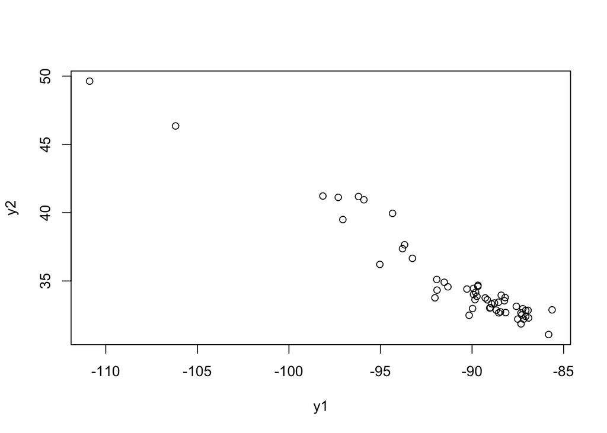

```r
x <- database
n = length(x[,1])

y1<- matrix(nrow = n)
for (i in 1:n){
  y1[i,1]<-t(eig$vector[,1])%*%t( x[i,])
}

y2<- matrix(nrow = n)
for (i in 1:n){
  y2[i,1]<-t(eig$vector[,2])%*%t(x[i,])
}
plot(y1,y2)
```

Therefore, $y1$ and $y2$ is linear correlated.

```r
order(y1)
```

```
##  [1] 11 46 40 33 47  5 15 36 34 24 52 41 21 51 32 26 12 23 31 53  8 44 10
## [24]  3 13 22 20 16 49  1 14 39  9 25 50 38 30  7 45 42 37 18 48 27 43 35
## [47]  2  4  6 28 19 17 29 54
```

Yes.

## Question Two

```r
matrix_quteiontwo <- matrix(c(5,2, 2, 2), nrow = 2, ncol = 2)
eig <- eigen(matrix_quteiontwo)
eig$values
```

```
## [1] 6 1
```

```r
sprintf('The proportion of y1 is %.5s',eig$values[1] / sum(eig$values))
```

```
## [1] "The proportion of y1 is 0.857"
```

## Question Three

```r
# datbase is from question one's code
database.cor <- cor(database)
y1.y2.cor <- database.cor[1:2,1:2]
eig <- eigen(y1.y2.cor)
sprintf('The proportion of y1 is %.5s',eig$values[1] / sum(eig$values))
```

```
## [1] "The proportion of y1 is 0.957"
```

Since the variances are not the same, the results are also different.

$\rho_{y1}, Z_1 = 0.707 \times \sqrt{1.6325} = 0.903$ $\rho_{y1}, Z_1 = 0.707 \times \sqrt{1.6325} = 0.903$ $\rho_{y2}, Z_1 = 0.707 \times \sqrt{=.3675} = 0.429$

## Question Four

$$\begin{bmatrix} \sigma^2 - \lambda & \sigma^2 \rho & 0 \\ \sigma^2 \rho & \sigma^2 - \lambda & \sigma^2 \rho \\ 0 & \sigma^2 \rho & \sigma^2 - \lambda \end{bmatrix} = 0$$
$$\begin{align*} &var(y1) = \lambda_1 = \sigma^2 \\ &var(y2) = \lambda_2 = \sigma^2(1 + \rho \sqrt{2}) \\ &var(y3) = \lambda_3 = \sigma^2 (1 - \rho \sqrt{2}) \end{align*}$$
$$\begin{align*} &y_1 = \frac{1}{\sqrt{2}} x_1 - \frac{1}{\sqrt{2}} x_2 \\ &y_2 = \frac{1}{2} x_1 + \frac{1}{\sqrt{2}} x_2 + \frac{1}{2} x_3 \\ &y_3 = \frac{1}{2} x_1 - \frac{1}{\sqrt{2}} x_2 + \frac{1}{2} x_3\end{align*}$$

```r
matrix <- matrix(c(1.00,0.02,0.96,0.42,0.01,0.02,1.00,0.13,0.71,0.85,0.96,0.13,1.00,0.50,0.11,0.42,0.71,0.50,1.00,0.79,0.01,0.85,0.11,0.79,1.00), nrow=5, ncol = 5)
# matrix
eigenvalue <- eigen(matrix)$value
eigenvector <- eigen(matrix)$vector
print(eigenvalue, eigenvector)
```

```
## [1] 3 2 0 0 0
```

```r
matrix.lambda <- matrix(rep(eigenvalue,5), nrow=5, byrow=TRUE)
l<-sqrt(eigenvalue) * eigenvector
l2 <- l[,1:2]
print(l2)
```

```
##             [,1]        [,2]
## [1,] -0.55986184  1.02565495
## [2,] -0.61845350 -0.52420211
## [3,] -0.17276854  0.25165635
## [4,] -0.17792082 -0.02498182
## [5,] -0.08672159 -0.07417421
```

```r
l3 = matrix(rep(eigenvalue,5),nrow = 5,byrow = TRUE)
l4<-sqrt(l3)*eigenvector
print(l4)
```

```
##            [,1]       [,2]        [,3]        [,4]         [,5]
## [1,] -0.5598618  0.8160981  0.04453561  0.04437464  0.128787099
## [2,] -0.7772594 -0.5242021  0.33579190 -0.09028161  0.013153309
## [3,] -0.6453364  0.7479464  0.07615553  0.03744292 -0.130059531
## [4,] -0.9391057 -0.1049187 -0.27203901 -0.18184384  0.000303964
## [5,] -0.7982069 -0.5432281 -0.09972820  0.24045880  0.001653934
```

```r
l<-matrix(c(0.56,0.78,0.65,0.94,0.80,0.82,-0.52,0.75,-0.10,-0.54),nrow=5)
varimax(l)
```

```
## $loadings
##
## Loadings:
##      [,1]   [,2]
## [1,]         0.993
## [2,]  0.937
## [3,]  0.135  0.983
## [4,]  0.842  0.430
## [5,]  0.965
##
##                 [,1]  [,2]
## SS loadings    2.538 2.137
## Proportion Var 0.508 0.427
## Cumulative Var 0.508 0.935
##
## $rotmat
##            [,1]      [,2]
## [1,]  0.8375788 0.5463165
## [2,] -0.5463165 0.8375788
```

## Question Five

```r
matrix_question_five <- matrix(c(1,0,63, 0.45, 0.63, 1.0, 0.35, 0.45, 0.35, 1.0), nrow = 3, ncol = 3)
lambda = c(0.9, 0.7, 0.5)
lambda %*% t(lambda)
```

```
##      [,1] [,2] [,3]
## [1,] 0.81 0.63 0.45
## [2,] 0.63 0.49 0.35
## [3,] 0.45 0.35 0.25
```

```r
Psi <- matrix(c(0.19, 0, 0, 0, 0.51, 0, 0, 0, 0.75), nrow = 3, ncol = 3)
phi = lambda %*% t(lambda) + Psi
print(phi)
```

```
##      [,1] [,2] [,3]
## [1,] 1.00 0.63 0.45
## [2,] 0.63 1.00 0.35
## [3,] 0.45 0.35 1.00
```

## Question Six

$$\begin{align*}h_1^2 = 0.9 \times 0.9 = 0.81 \\ h_2^2 = 0.7 \times 0.7 = 0.49 \\ h_3^2 = 0.5 \times 0.5 = 0.25\end{align*}$$

$$\begin{align*} Corr(Z_1, F_1) = L_{11} - 0.9 \\ Corr(Z_2, F_1) = L_{21} = 0.7 \\ Corr(Z_3, F_1) = L_{31} = 0.5 \end{align*}$$

## Question Seven

$$\begin{align*} &L_{11} = 0.717 \text{ or} - 0.717 \\ &L_{21} = 0.558 \text{ or} - 0.558 \\
&L_{31} = 1.255 \text{ or} - 1.255 \end{align*}$$

$$\begin{align*}
&\Psi1 = 1 -0.514 = 0.486\\
&\Psi2 = 1-0.311 = 0.689 \\
&\Psi3 = 1- 1.575 = - 0.575\end{align*}$$